# Q2. Distance Matrix Computation with k-NN Classification

**Objectives:**

- Check **missing values** and impute using **PDF (Probability Distribution Function)** to choose central tendency.
- **Standardize** features.
- Compute pairwise distance matrices using **Euclidean** and **Manhattan** via `sklearn.metrics.pairwise_distances`.
- Use the distance matrix with **k-Nearest Neighbors** classification.
- Apply **cross-validation** with a **heuristic (elbow) method** to find optimal `k`.
- Report the best **F1 score** and **Precision**.

**Environment:** `uv` with scikit-learn, numpy, pandas, matplotlib, seaborn.

```python
import numpy as np
import pandas as pd
import matplotlib.pyplot as plt
import seaborn as sns
from pathlib import Path
from scipy.stats import skew
from sklearn.metrics.pairwise import pairwise_distances
from sklearn.model_selection import cross_val_score, StratifiedKFold
from sklearn.neighbors import KNeighborsClassifier
from sklearn.preprocessing import StandardScaler, LabelEncoder
from sklearn.metrics import make_scorer, precision_score

print("numpy:", np.__version__)
print("pandas:", pd.__version__)
print("seaborn:", sns.__version__)
```

```
numpy: 2.5.0
pandas: 3.0.3
seaborn: 0.13.2
```

## 1. Load Dataset & Check Missing Values

```python
BASE_DIR = Path(".")
df = pd.read_excel(BASE_DIR / "lab2 data.xlsx")

print(f"Original shape: {df.shape}")
print(f"Columns: {df.columns.tolist()}\n")

# Check missing values
missing = df.isnull().sum()
missing_pct = (missing / len(df)) * 100
missing_df = pd.DataFrame({'Missing Count': missing, 'Missing %': missing_pct.round(2)})
missing_df = missing_df[missing_df['Missing Count'] > 0].sort_values('Missing %', ascending=False)

if missing_df.empty:
    print("No missing values found in any column.")
else:
    print("Columns with missing values:")
    display(missing_df)
```

```
Original shape: (163, 14)
Columns: ['Timestamp', 'Reg No', 'Job role that you are interested in', 'What is the minimum salary of students placed through campus (In LPA..respond as a number)', 'What is the maximum salary of students placed through campus (In LPA..respond as a number)', 'What is the  median salary of students …

Columns with missing values:
```

|  | Missing Count | Missing % |
| --- | --- | --- |
| Internships Interests | 25 | 15.34 |
| your CIA % of last semester | 11 | 6.75 |
| your GPA of last semester | 7 | 4.29 |
| What is the median salary of students placed through campus (In LPA..respond as a number) | 6 | 3.68 |
| What is the maximum salary of students placed through campus (In LPA..respond as a number) | 5 | 3.07 |
| Your maximum attendance % till last semester | 5 | 3.07 |
| Job role that you are interested in | 1 | 0.61 |
| What is the minimum salary of students placed through campus (In LPA..respond as a number) | 1 | 0.61 |
| Which is the highest paying company | 1 | 0.61 |
| Rate your contribution towards extra curricular activities | 1 | 0.61 |
| What are your package expectations (LPA) | 1 | 0.61 |

## 2. Select Features, Clean & Check Missing Within Selected

```python
# Select feature columns and target
n_features = df[[
    'Rate your contribution towards extra curricular activities',
    'Rate your technical competencies',
    'your CIA % of last semester',
    'Your maximum attendance % till last semester'
]].copy()

target = df['Internships Interests'].copy()

# --- Clean CIA, Attendance ---
def clean_pct(col):
    vals = pd.to_numeric(col, errors='coerce')
    mask = vals <= 1
    vals[mask] = vals[mask] * 100
    return vals

n_features['CIA_pct'] = clean_pct(n_features['your CIA % of last semester'])
n_features['Attend_pct'] = clean_pct(n_features['Your maximum attendance % till last semester'])

feature_cols = [
    'Rate your contribution towards extra curricular activities',
    'Rate your technical competencies',
    'CIA_pct',
    'Attend_pct'
]

# Rename for convenience
rename_map = {
    'Rate your contribution towards extra curricular activities': 'ExtraCurricular',
    'Rate your technical competencies': 'TechRating',
}
df_work = n_features[feature_cols].rename(columns=rename_map)
work_cols = ['ExtraCurricular', 'TechRating', 'CIA_pct', 'Attend_pct']

print("Feature matrix shape:", df_work.shape)
print(f"\nMissing values in selected features:\n{df_work.isnull().sum()}")
```

```
Feature matrix shape: (163, 4)

Missing values in selected features:
ExtraCurricular     1
TechRating          0
CIA_pct            13
Attend_pct          6
dtype: int64
```

## 3. PDF-Based Imputation of Central Tendencies

For each numeric feature, we plot its **Probability Distribution Function (PDF)** (via histogram + KDE) and measure **skewness** to decide the imputation strategy:

- **Symmetric / near-zero skew (~ -0.5 to 0.5)** → **Mean** imputation
- **Skewed (|skew| > 0.5)** → **Median** imputation (robust to outliers)
- **Discrete / categorical-like** → **Mode** imputation

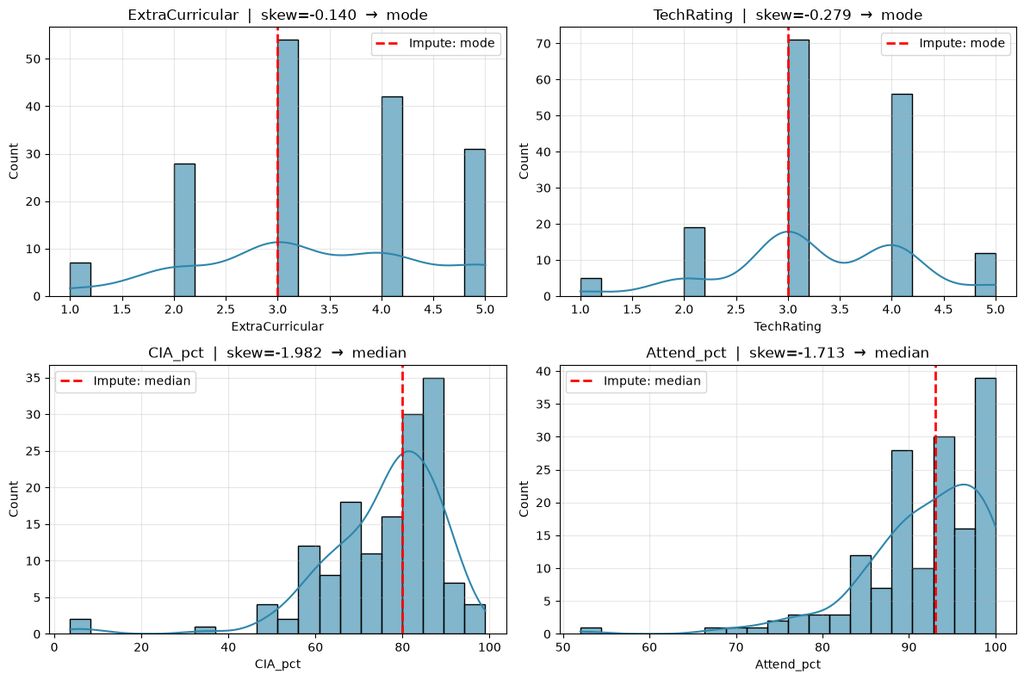

```
Imputation strategies based on PDF analysis:
  ExtraCurricular       skew=-0.140  →  mode    (value=3.0)
  TechRating            skew=-0.279  →  mode    (value=3)
  CIA_pct               skew=-1.982  →  median  (value=80.0)
  Attend_pct            skew=-1.713  →  median  (value=93.0)
```

```python
fig, axes = plt.subplots(2, 2, figsize=(12, 8))
axes = axes.flatten()

impute_strategies = {}

for idx, col in enumerate(work_cols):
    ax = axes[idx]
    series = df_work[col].dropna()

    # Plot PDF: histogram + KDE
    sns.histplot(series, kde=True, bins=20, ax=ax, color='#2E86AB', alpha=0.6)

    # Compute skewness
    s = skew(series)

    # Decide strategy
    unique_vals = series.nunique()
    if unique_vals <= 5:
        strategy = 'mode'
        impute_val = series.mode().iloc[0]
    elif abs(s) <= 0.5:
        strategy = 'mean'
        impute_val = series.mean()
    else:
        strategy = 'median'
        impute_val = series.median()

    impute_strategies[col] = {'strategy': strategy, 'value': round(impute_val, 2), 'skew': round(s, 3)}

    ax.axvline(impute_val, color='red', linestyle='--', linewidth=2, label=f"Impute: {strategy}")
    ax.set_title(f"{col}  |  skew={s:.3f}  →  {strategy}")
    ax.legend()
    ax.grid(True, alpha=0.3)

plt.tight_layout()
plt.show()

print("Imputation strategies based on PDF analysis:")
for col, info in impute_strategies.items():
    print(f"  {col:20s}  skew={info['skew']:>6.3f}  →  {info['strategy']:6s}  (value={info['value']})")
```

### Apply the chosen imputation

```python
df_imputed = df_work.copy()

for col in work_cols:
    info = impute_strategies[col]
    missing_before = df_imputed[col].isnull().sum()

    if info['strategy'] == 'mode':
        val = df_imputed[col].mode().iloc[0]
    elif info['strategy'] == 'median':
        val = df_imputed[col].median()
    else:
        val = df_imputed[col].mean()

    df_imputed[col] = df_imputed[col].fillna(val)

    if missing_before > 0:
        print(f"{col:20s}  filled {missing_before} missing values with {info['strategy']} ({val:.2f})")

print(f"\nMissing after imputation:\n{df_imputed.isnull().sum()}")
```

```
ExtraCurricular       filled 1 missing values with mode (3.00)
CIA_pct               filled 13 missing values with median (80.00)
Attend_pct            filled 6 missing values with median (93.00)

Missing after imputation:
ExtraCurricular    0
TechRating         0
CIA_pct            0
Attend_pct         0
dtype: int64
```

## 4. Prepare Target & Encode

```python
# Combine with target and drop any remaining NaN rows
valid = target.notna()
X_raw = df_imputed[valid].astype(float)
y_raw = target[valid]

le = LabelEncoder()
y_clean = le.fit_transform(y_raw)

print(f"Samples: {len(X_raw)}")
print(f"Target distribution:\n{pd.Series(y_clean).value_counts()}")
print(f"Class mapping: {dict(zip(le.classes_, le.transform(le.classes_)))}")
print(f"\nFirst 5 rows:\n{X_raw.head()}")
```

```
Samples: 138
Target distribution:
0    99
1    39
Name: count, dtype: int64
Class mapping: {'Industry': np.int64(0), 'Research': np.int64(1)}

First 5 rows:
   ExtraCurricular  TechRating  CIA_pct  Attend_pct
0              3.0         4.0     60.0        77.0
1              3.0         2.0     67.0        97.0
2              3.0         4.0     80.0        99.0
3              3.0         3.0     75.0        95.0
4              3.0         3.0     65.0        96.0
```

## 5. Standardize Features

Distance-based algorithms are sensitive to feature scales. We apply Z-score standardization.

```python
scaler = StandardScaler()
X_scaled = scaler.fit_transform(X_raw)

print("Post-standardization:")
print("  means:", X_scaled.mean(axis=0).round(6))
print("  stds: ", X_scaled.std(axis=0).round(6))
```

```
Post-standardization:
  means: [-0.  0. -0.  0.]
  stds:  [1. 1. 1. 1.]
```

## 6. Compute Pairwise Distance Matrices

Using `sklearn.metrics.pairwise_distances` with two metrics.

```python
D_euclidean = pairwise_distances(X_scaled, metric='euclidean')
D_manhattan = pairwise_distances(X_scaled, metric='manhattan')

print(f"Euclidean distance matrix shape: {D_euclidean.shape}")
print(f"Manhattan distance matrix shape: {D_manhattan.shape}")
print(f"\nEuclidean distances (first 5x5):")
print(np.round(D_euclidean[:5, :5], 3))
print(f"\nManhattan distances (first 5x5):")
print(np.round(D_manhattan[:5, :5], 3))
```

```
Euclidean distance matrix shape: (138, 138)
Manhattan distance matrix shape: (138, 138)

Euclidean distances (first 5x5):
[[0.    3.686 3.376 2.97  2.903]
 [3.686 0.    2.591 1.362 1.212]
 [3.376 2.591 0.    1.367 1.683]
 [2.97  1.362 1.367 0.    0.754]
 [2.903 1.212 1.683 0.754 0.   ]]

Manhattan distances (first 5x5):
[[0.    5.666 4.515 4.788 4.185]
 [5.666 0.    3.629 2.063 1.481]
 [4.515 3.629 0.    2.117 2.72 ]
 [4.788 2.063 2.117 0.    0.879]
 [4.185 1.481 2.72  0.879 0.   ]]
```

## 7. k-NN with Cross-Validation & Heuristic (Elbow) Method

Train k-NN using **precomputed distance matrices**. Evaluate k=1..30 with 5-fold **Stratified CV**, tracking **F1 (macro)** and **Precision (macro)** to find the best k via the elbow heuristic.

```python
k_range = range(1, 31)
cv = StratifiedKFold(n_splits=5, shuffle=True, random_state=42)

results = []

for metric_name, D in [('Euclidean', D_euclidean), ('Manhattan', D_manhattan)]:
    f1_scores = []
    prec_scores = []

    for k in k_range:
        knn = KNeighborsClassifier(n_neighbors=k, metric='precomputed')

        f1 = cross_val_score(knn, D, y_clean, cv=cv, scoring='f1_macro')
        prec = cross_val_score(knn, D, y_clean, cv=cv,
                               scoring=make_scorer(precision_score, average='macro', zero_division=0))

        f1_scores.append(f1.mean())
        prec_scores.append(prec.mean())

        results.append({
            'Distance Metric': metric_name,
            'k': k,
            'F1 (macro)': round(f1.mean(), 4),
            'Precision (macro)': round(prec.mean(), 4)
        })

    best_idx = np.argmax(f1_scores)
    best_k = k_range[best_idx]
    print(f"[{metric_name}] Best k = {best_k}  |  F1 = {f1_scores[best_idx]:.4f}  |  Precision = {prec_scores[best_idx]:.4f}")

results_df = pd.DataFrame(results)
print("\nAll results:")
display(results_df)
```

```
[Euclidean] Best k = 3  |  F1 = 0.5900  |  Precision = 0.6435
```

```
[Manhattan] Best k = 5  |  F1 = 0.5944  |  Precision = 0.6245

All results:
```

|  | Distance Metric | k | F1 (macro) | Precision (macro) |
| --- | --- | --- | --- | --- |
| 0 | Euclidean | 1 | 0.5496 | 0.5522 |
| 1 | Euclidean | 2 | 0.5194 | 0.6181 |
| 2 | Euclidean | 3 | 0.5900 | 0.6435 |
| 3 | Euclidean | 4 | 0.5861 | 0.7059 |
| 4 | Euclidean | 5 | 0.5871 | 0.6392 |
| 5 | Euclidean | 6 | 0.5872 | 0.7274 |
| 6 | Euclidean | 7 | 0.5801 | 0.6392 |
| 7 | Euclidean | 8 | 0.5142 | 0.6185 |
| 8 | Euclidean | 9 | 0.5375 | 0.5644 |
| 9 | Euclidean | 10 | 0.5042 | 0.5734 |
| 10 | Euclidean | 11 | 0.5521 | 0.6023 |
| 11 | Euclidean | 12 | 0.4606 | 0.4939 |
| 12 | Euclidean | 13 | 0.4851 | 0.5064 |
| 13 | Euclidean | 14 | 0.4541 | 0.4932 |
| 14 | Euclidean | 15 | 0.4923 | 0.5262 |
| 15 | Euclidean | 16 | 0.4541 | 0.4932 |
| 16 | Euclidean | 17 | 0.4599 | 0.5241 |
| 17 | Euclidean | 18 | 0.4339 | 0.4568 |
| 18 | Euclidean | 19 | 0.4412 | 0.4723 |
| 19 | Euclidean | 20 | 0.4124 | 0.3564 |
| 20 | Euclidean | 21 | 0.4255 | 0.3819 |
| 21 | Euclidean | 22 | 0.4418 | 0.4614 |
| 22 | Euclidean | 23 | 0.4562 | 0.4620 |
| 23 | Euclidean | 24 | 0.4177 | 0.3587 |
| 24 | Euclidean | 25 | 0.4418 | 0.4614 |
| 25 | Euclidean | 26 | 0.4177 | 0.3587 |
| 26 | Euclidean | 27 | 0.4177 | 0.3587 |
| 27 | Euclidean | 28 | 0.4177 | 0.3587 |
| 28 | Euclidean | 29 | 0.4417 | 0.4614 |
| 29 | Euclidean | 30 | 0.4177 | 0.3587 |
| 30 | Manhattan | 1 | 0.5338 | 0.5381 |
| 31 | Manhattan | 2 | 0.5113 | 0.6058 |
| 32 | Manhattan | 3 | 0.5631 | 0.5756 |
| 33 | Manhattan | 4 | 0.5853 | 0.7226 |
| 34 | Manhattan | 5 | 0.5944 | 0.6245 |
| 35 | Manhattan | 6 | 0.5736 | 0.7189 |
| 36 | Manhattan | 7 | 0.5769 | 0.6206 |
| 37 | Manhattan | 8 | 0.5347 | 0.6700 |
| 38 | Manhattan | 9 | 0.5805 | 0.6300 |
| 39 | Manhattan | 10 | 0.4774 | 0.5627 |
| 40 | Manhattan | 11 | 0.5498 | 0.6996 |
| 41 | Manhattan | 12 | 0.5180 | 0.6034 |
| 42 | Manhattan | 13 | 0.5164 | 0.5842 |
| 43 | Manhattan | 14 | 0.4476 | 0.4107 |
| 44 | Manhattan | 15 | 0.4790 | 0.5511 |
| 45 | Manhattan | 16 | 0.4695 | 0.5436 |
| 46 | Manhattan | 17 | 0.4836 | 0.5651 |
| 47 | Manhattan | 18 | 0.4259 | 0.4545 |
| 48 | Manhattan | 19 | 0.4835 | 0.5537 |
| 49 | Manhattan | 20 | 0.4074 | 0.3543 |
| 50 | Manhattan | 21 | 0.4045 | 0.3530 |
| 51 | Manhattan | 22 | 0.4126 | 0.3565 |
| 52 | Manhattan | 23 | 0.4502 | 0.4280 |
| 53 | Manhattan | 24 | 0.4393 | 0.4604 |
| 54 | Manhattan | 25 | 0.4319 | 0.4083 |
| 55 | Manhattan | 26 | 0.4418 | 0.4614 |
| 56 | Manhattan | 27 | 0.4658 | 0.5641 |
| 57 | Manhattan | 28 | 0.4177 | 0.3587 |
| 58 | Manhattan | 29 | 0.4177 | 0.3587 |
| 59 | Manhattan | 30 | 0.4177 | 0.3587 |

## 8. Heuristic (Elbow) Plot

The elbow heuristic looks for the k where the F1 score plateaus.

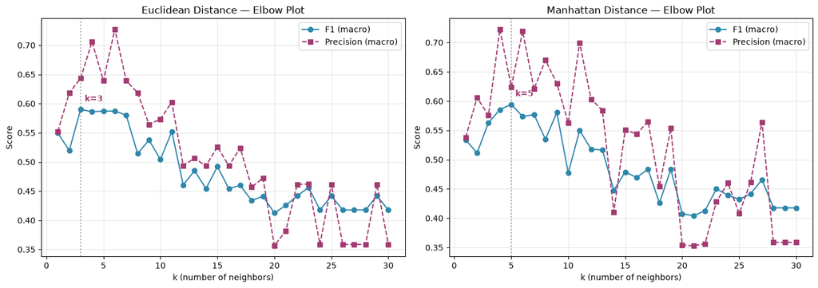

```python
fig, axes = plt.subplots(1, 2, figsize=(14, 5))

for idx, metric_name in enumerate(['Euclidean', 'Manhattan']):
    subset = results_df[results_df['Distance Metric'] == metric_name]
    ax = axes[idx]

    ax.plot(subset['k'], subset['F1 (macro)'], 'o-', label='F1 (macro)', color='#2E86AB')
    ax.plot(subset['k'], subset['Precision (macro)'], 's--', label='Precision (macro)', color='#A23B72')

    best_row = subset.loc[subset['F1 (macro)'].idxmax()]
    ax.axvline(best_row['k'], color='gray', linestyle=':', alpha=0.7)
    ax.annotate(f"k={int(best_row['k'])}",
                xy=(best_row['k'], best_row['F1 (macro)']),
                xytext=(5, 10), textcoords='offset points',
                fontsize=10, fontweight='bold', color='#A23B72')

    ax.set_xlabel('k (number of neighbors)')
    ax.set_ylabel('Score')
    ax.set_title(f'{metric_name} Distance — Elbow Plot')
    ax.legend()
    ax.grid(True, alpha=0.3)

plt.tight_layout()
plt.show()
```

## 9. Best Result Summary

```python
print("=== Best Configuration for Each Distance Metric ===\n")

for metric_name in ['Euclidean', 'Manhattan']:
    subset = results_df[results_df['Distance Metric'] == metric_name]
    best = subset.loc[subset['F1 (macro)'].idxmax()]
    print(f"{metric_name}:")
    print(f"  Optimal k (elbow): {int(best['k'])}")
    print(f"  F1 Score (macro):  {best['F1 (macro)']}")
    print(f"  Precision (macro): {best['Precision (macro)']}")
    print()

global_best = results_df.loc[results_df['F1 (macro)'].idxmax()]
print(f"*** Global Best ***")
print(f"  Distance: {global_best['Distance Metric']}")
print(f"  k = {int(global_best['k'])}")
print(f"  F1 (macro)  = {global_best['F1 (macro)']}")
print(f"  Precision (macro) = {global_best['Precision (macro)']}")
```

```
=== Best Configuration for Each Distance Metric ===

Euclidean:
  Optimal k (elbow): 3
  F1 Score (macro):  0.59
  Precision (macro): 0.6435

Manhattan:
  Optimal k (elbow): 5
  F1 Score (macro):  0.5944
  Precision (macro): 0.6245

*** Global Best ***
  Distance: Manhattan
  k = 5
  F1 (macro)  = 0.5944
  Precision (macro) = 0.6245
```

### Pipeline Summary

| Step | Detail |
| --- | --- |
| 1. Missing Value Check | Count and % of nulls per column |
| 2. PDF Imputation | Plot distribution + KDE; measure skew; choose mean/median/mode |
| 3. Standardization | Z-score scaling (mean=0, std=1) |
| 4. Distance Matrices | `pairwise_distances` with Euclidean & Manhattan |
| 5. k-NN CV (5-fold) | k=1..30 with precomputed distance |
| 6. Elbow Heuristic | Plateau detection on F1 vs k plot |
| 7. Best Metrics | F1 (macro) & Precision (macro) reported |